# R Notebook

# Instalaci?n de Paquetes

Libreria para missing VIM MICE simputation AMELIA

```r
install.packages(c("VIM","DEoptimR","minqa","nloptr","DMwR", "simputation"),
                 dependencies = c("Depends"))
```

# Diagn?stico de datos perdidos

Indicadores de medidiciones del mar

```r
install.packages("robustbase")
```

```r
install.packages("laeken")
```

```r
install.packages("ranger")
```

```r
library(ranger)
library(laeken)
library(robustbase)
library(VIM)
data(tao)
head(tao)
```

|  | Year | Latitude | Longitude | Sea.Surface.Temp | Air.Temp | Humidity | UWind | VWind |
| --- | --- | --- | --- | --- | --- | --- | --- | --- |
| 1 | 1997 | 0 | -110 | 27.59 | 27.15 | 79.6 | -6.4 | 5.4 |
| 2 | 1997 | 0 | -110 | 27.55 | 27.02 | 75.8 | -5.3 | 5.3 |
| 3 | 1997 | 0 | -110 | 27.57 | 27.00 | 76.5 | -5.1 | 4.5 |
| 4 | 1997 | 0 | -110 | 27.62 | 26.93 | 76.2 | -4.9 | 2.5 |
| 5 | 1997 | 0 | -110 | 27.65 | 26.84 | 76.4 | -3.5 | 4.1 |
| 6 | 1997 | 0 | -110 | 27.83 | 26.94 | 76.7 | -4.4 | 1.6 |

```r
help(tao) #https://en.wikipedia.org/wiki/Tropical_Atmosphere_Ocean_project
```

La funcion nos devuelve datos perdidos (NA)

```r
summary(tao)
```

```
      Year         Latitude        Longitude      Sea.Surface.Temp
 Min.   :1993   Min.   :-5.000   Min.   :-110.0   Min.   :21.60
 1st Qu.:1993   1st Qu.:-2.000   1st Qu.:-110.0   1st Qu.:23.50
 Median :1995   Median :-1.000   Median :-102.5   Median :26.55
 Mean   :1995   Mean   :-1.375   Mean   :-102.5   Mean   :25.86
 3rd Qu.:1997   3rd Qu.: 0.000   3rd Qu.: -95.0   3rd Qu.:28.21
 Max.   :1997   Max.   : 0.000   Max.   : -95.0   Max.   :30.17
                                                  NA's   :3
    Air.Temp        Humidity         UWind            VWind
 Min.   :21.42   Min.   :71.60   Min.   :-8.100   Min.   :-6.200
 1st Qu.:23.26   1st Qu.:81.30   1st Qu.:-5.100   1st Qu.: 1.500
 Median :24.52   Median :85.20   Median :-3.900   Median : 2.900
 Mean   :25.03   Mean   :84.43   Mean   :-3.716   Mean   : 2.636
 3rd Qu.:27.08   3rd Qu.:88.10   3rd Qu.:-2.600   3rd Qu.: 4.100
 Max.   :28.50   Max.   :94.80   Max.   : 4.300   Max.   : 7.300
 NA's   :81      NA's   :93
```

Para ver la cantidad datos perdidos

```r
#Para ver que columnas tienen valores perdidos
which(colSums(is.na(tao))!=0)
```

```
Sea.Surface.Temp         Air.Temp         Humidity
               4                5                6
```

#Para ver el porcentaje de valores perdidos en las columnas

```r
colmiss=c(4,5,6)
per.miss.col=100*colSums(is.na(tao[,colmiss]))/dim(tao)[1]
per.miss.col
```

```
Sea.Surface.Temp         Air.Temp         Humidity
       0.4076087       11.0054348       12.6358696
```

Se debe usar mecanismo para la generacion de los datos, debemos usar algun mecanismo para la generacion de los datos.

```
not enough horizontal space to display frequencies
```

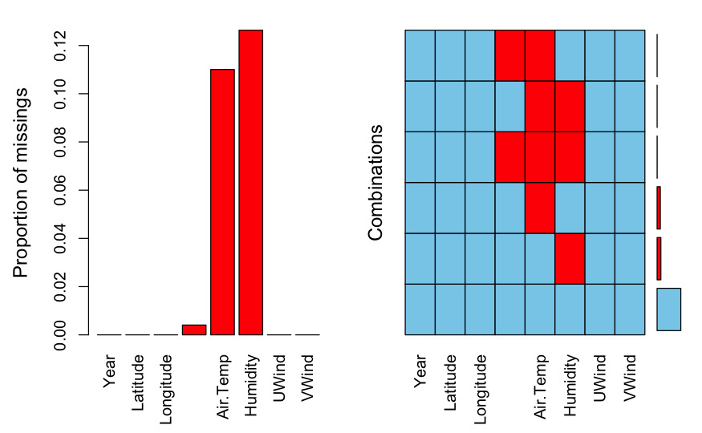

```r
# Aggregation plot
a=aggr(tao,numbers=T)
```

Si se ve el color rojo es que se perdieron datos

Tengo un 76.77% de filas completas Tengo un 12.23% que tiene datos faltantes para la variable humedad Tengo un 0.27% que se han perdido datos en simultaneo para la humedad, temperatura del aire y temperatura en la superficie del mar.

CONCLUSION: Se observa que hay 2 variables que tienen datos perdidos mayores a 10%, por lo tanto son altos

```r
a
```

```
 Missings in variables:
```

|  | Variable | Count |
| --- | --- | --- |
| Sea.Surface.Temp | Sea.Surface.Temp | 3 |
| Air.Temp | Air.Temp | 81 |
| Humidity | Humidity | 93 |

```r
summary(a)
```

```
 Missings per variable:
```

|  | Variable | Count |
| --- | --- | --- |
| Year | Year | 0 |
| Latitude | Latitude | 0 |
| Longitude | Longitude | 0 |
| Sea.Surface.Temp | Sea.Surface.Temp | 3 |
| Air.Temp | Air.Temp | 81 |
| Humidity | Humidity | 93 |
| UWind | UWind | 0 |
| VWind | VWind | 0 |

```
 Missings in combinations of variables:
```

| Combinations | Count | Percent |
| --- | --- | --- |
| 0:0:0:0:0:0:0:0 | 565 | 76.7663043 |
| 0:0:0:0:0:1:0:0 | 90 | 12.2282609 |
| 0:0:0:0:1:0:0:0 | 77 | 10.4619565 |
| 0:0:0:0:1:1:0:0 | 1 | 0.1358696 |
| 0:0:0:1:1:0:0:0 | 1 | 0.1358696 |
| 0:0:0:1:1:1:0:0 | 2 | 0.2717391 |

[output not shown]

```
 Variables sorted by number of missings:
```

| Variable | Count |
| --- | --- |
| Humidity | 0.126358696 |
| Air.Temp | 0.110054348 |
| Sea.Surface.Temp | 0.004076087 |
| Year | 0.000000000 |
| Latitude | 0.000000000 |
| Longitude | 0.000000000 |
| UWind | 0.000000000 |
| VWind | 0.000000000 |

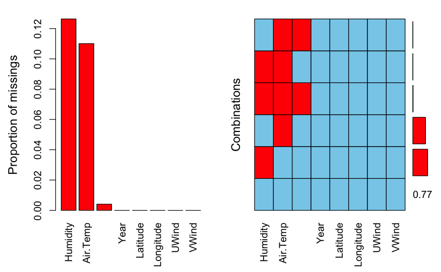

```r
aggr(tao,numbers=T, sortComb=TRUE, sortVar=TRUE, only.miss=TRUE)
```

MAR –> Color fijo MCAR –> Calores variables

Patron de tipo MAR : porque la perdida de la humedad esta relacionado con la temperatura del aire baja, en el primer anho

# Mecanismo: ?MCAR o MAR?

```
Click in a column to sort by the corresponding variable.
To regain use of the VIM GUI and the R console, click outside the plot region.
```

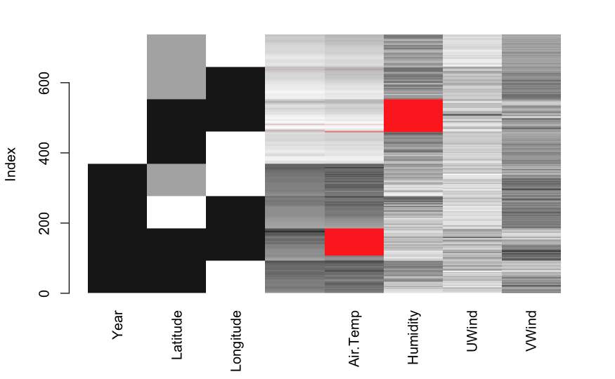

```r
# Matrix plot
matrixplot(tao)
```

Cuando la variable de temperatura es alta, se pierden la temperatura del aire solo para el primer anho

```
Click in in the left margin to switch to the previous variable or in the right margin to switch to the next variable.
To regain use of the VIM GUI and the R console, click anywhere else in the graphics window.
```

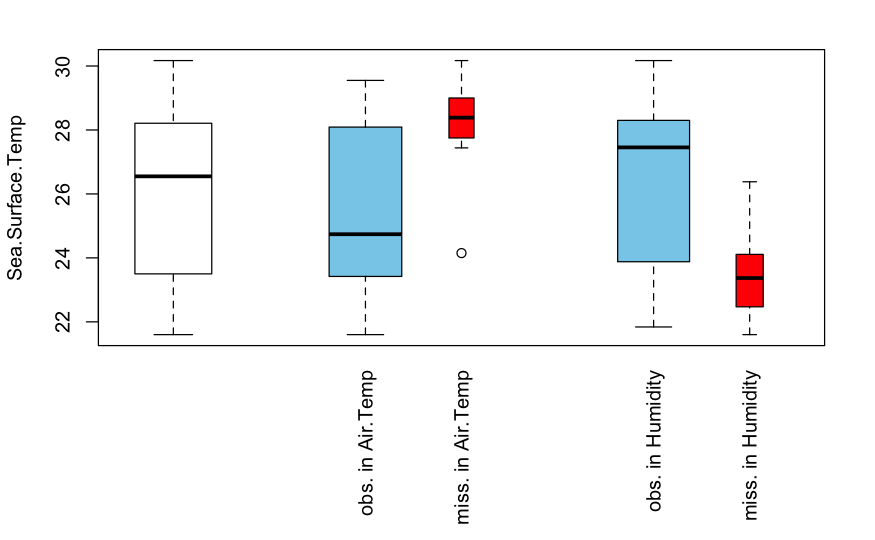

```r
#Parallel boxplots
VIM::pbox(tao[4:6], pos=1)  # la varable de la temperatura del mar - pos =1
```

1er grafico : Temperatura de la superficie del mar es mostrada con todas las variables 2do grafico : Sin missing de la variable de la temperatura del aire 3er grafico : Con missing de la variable de la temperatura del aire

#————————————————— Si el mecanismo es el MAR las cajas deben ser diferentes Si el mecanismo es MCAR las cajas deberian ser iguales #—————————————————

Si la temperatura del mar es alta se pierden los datos de la temperatura del aire

Si la temperatura del mar es bajo de lo usual se pierden los datos de la humedad

# Se suele usar los graficos de dispersion

Diagrama de dispersion entre las variables que tienen mayor cantidad de datos perdidos

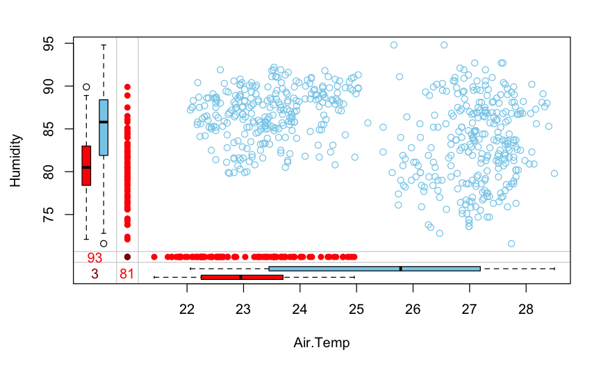

```r
# Gr?ficos de dispersi?n
marginplot(tao[,c("Air.Temp", "Humidity")])
```

# Supuestos para hacer la prueba de medias

- Los valores deben ser obtenidos datos aleatorios
- Deben venir de una distribucion normal

# Prueba de medias

H0: $mu_{NM}$ = $mu_{M}$ H1: $mu_{NM}$ != $mu_{M}$ –> MAR

```r
# Prueba t de medias
t.test(Sea.Surface.Temp ~ is.na(Humidity), data=tao)
```

```
    Welch Two Sample t-test

data:  Sea.Surface.Temp by is.na(Humidity)
t = 18.404, df = 224.98, p-value < 2.2e-16
alternative hypothesis: true difference in means is not equal to 0
95 percent confidence interval:
 2.496769 3.095537
sample estimates:
mean in group FALSE  mean in group TRUE
           26.21209            23.41593
```

Como el p es casi cero, se tiene evidencia para descartar la hipotesis nula , por lo tanto podemos asumir que la medias son distintas y se acepta el mecanismo MAR

NOTA : Se observa que no se probaron ninguna prueba por lo tanto el valor obtenido es solo un mecanismo referencial

# Solucion:

- Eliminar (eliminar filas) , solo se usa en el caso trivial
- Reemplazar (imputar), reemplazar el valor faltante con el valor de medida central : media, mediana o moda . Se aplica cuando el mecanismo sea MCAR y si es manejable. Un mecanismo mas complejo podria ser una regresion ( cuando el mecanismo es MAR y es manejable).

  Si el porcentaje es de 5 a 15% de datos faltantes y es MAR, se puede usar un mecanismo de regresion. Por ejemplo los modelos que podrian usarse seria ( estos modelos ya han sido estudiados por otras personas) * Maquina de Soporte Vectorial * Regresion Multiple * Boosting

  Las librerias para imputacion complejas son : VIM y simputacion
- Mantener

# Eliminaci?n de casos (solo si es trivial)

No se debe hacer eso, pero es una forma de mostrar como usar la funcion

```r
tao.cl=na.omit(tao)
```

# Imputaci?n

```r
install.packages("ROCR")
```

```r
#----------------------------------------#
# Usando una medida de Tendencia Central #
#----------------------------------------#
library(DMwR)
tao.c<-centralImputation(tao)
tao.d<-initialise(tao,method="median")
```

```r
summary(tao.d)
```

```
      Year         Latitude        Longitude      Sea.Surface.Temp    Air.Temp
 Min.   :1993   Min.   :-5.000   Min.   :-110.0   Min.   :21.60    Min.   :21.42
 1st Qu.:1993   1st Qu.:-2.000   1st Qu.:-110.0   1st Qu.:23.52    1st Qu.:23.38
 Median :1995   Median :-1.000   Median :-102.5   Median :26.55    Median :24.52
 Mean   :1995   Mean   :-1.375   Mean   :-102.5   Mean   :25.87    Mean   :24.97
 3rd Qu.:1997   3rd Qu.: 0.000   3rd Qu.: -95.0   3rd Qu.:28.21    3rd Qu.:26.99
 Max.   :1997   Max.   : 0.000   Max.   : -95.0   Max.   :30.17    Max.   :28.50
    Humidity         UWind            VWind
 Min.   :71.60   Min.   :-8.100   Min.   :-6.200
 1st Qu.:81.70   1st Qu.:-5.100   1st Qu.: 1.500
 Median :85.20   Median :-3.900   Median : 2.900
 Mean   :84.53   Mean   :-3.716   Mean   : 2.636
 3rd Qu.:87.70   3rd Qu.:-2.600   3rd Qu.: 4.100
 Max.   :94.80   Max.   : 4.300   Max.   : 7.300
```

```r
install.packages("gower")
```

```r
#----------------------------------------#
# Usando Modelos de Regresi?n            #
#----------------------------------------#

library(simputation)
```

$y_i = beta_0 + beta_1*x_1 + beta_2*x_2 + ... + beta_{pi}*x_{pi} + error$

$y_i = mu_{y/(x media)} + error$

$y_i = beta_0*1 + error$

En el ultimo caso la media de la poblacion es gual a la media del estadistico

```r
## Reemplazando por la media
tao.i <- impute_lm(tao, Air.Temp + Humidity ~ 1) # voy a imputar en paralelo a las variables Air.Temp y Humidity . El 1 es por el modelo lineal con beta0
tao[c(108:110, 463,551:552),]
```

|  | Year | Latitude | Longitude | Sea.Surface.Temp | Air.Temp | Humidity | UWind | VWind |
| --- | --- | --- | --- | --- | --- | --- | --- | --- |
| 108 | 1997 | 0 | -95 | 27.69 | NA | 79.8 | -0.6 | 4.2 |
| 109 | 1997 | 0 | -95 | 27.63 | NA | 74.5 | -3.9 | 5.8 |
| 110 | 1997 | 0 | -95 | 27.51 | NA | 76.3 | -2.8 | 5.3 |
| 463 | 1993 | 0 | -95 | NA | NA | NA | -5.6 | 3.1 |
| 551 | 1993 | 0 | -95 | 24.78 | 24.76 | NA | -1.8 | 2.3 |
| 552 | 1993 | 0 | -95 | 24.79 | 24.49 | NA | -1.4 | 3.4 |

```r
mean(tao$Air.Temp, na.rm = TRUE)
```

```
[1] 25.02925
```

```r
mean(tao$Humidity, na.rm = TRUE)
```

```
[1] 84.43499
```

```r
tao.i[c(108:110, 463,551:552),]
```

|  | Year | Latitude | Longitude | Sea.Surface.Temp | Air.Temp | Humidity | UWind | VWind |
| --- | --- | --- | --- | --- | --- | --- | --- | --- |
| 108 | 1997 | 0 | -95 | 27.69 | 25.02925 | 79.80000 | -0.6 | 4.2 |
| 109 | 1997 | 0 | -95 | 27.63 | 25.02925 | 74.50000 | -3.9 | 5.8 |
| 110 | 1997 | 0 | -95 | 27.51 | 25.02925 | 76.30000 | -2.8 | 5.3 |
| 463 | 1993 | 0 | -95 | NA | 25.02925 | 84.43499 | -5.6 | 3.1 |
| 551 | 1993 | 0 | -95 | 24.78 | 24.76000 | 84.43499 | -1.8 | 2.3 |
| 552 | 1993 | 0 | -95 | 24.79 | 24.49000 | 84.43499 | -1.4 | 3.4 |

```r
NA
```

Valor estocastico del error ## Reemplazando por la media de cada anho

```r
tao.i <- impute_lm(tao, Air.Temp + Humidity ~ 1 | Year)
```

```r
tao[c(108:110, 463,551:552),]
```

|  | Year | Latitude | Longitude | Sea.Surface.Temp | Air.Temp | Humidity | UWind | VWind |
| --- | --- | --- | --- | --- | --- | --- | --- | --- |
| 108 | 1997 | 0 | -95 | 27.69 | NA | 79.8 | -0.6 | 4.2 |
| 109 | 1997 | 0 | -95 | 27.63 | NA | 74.5 | -3.9 | 5.8 |
| 110 | 1997 | 0 | -95 | 27.51 | NA | 76.3 | -2.8 | 5.3 |
| 463 | 1993 | 0 | -95 | NA | NA | NA | -5.6 | 3.1 |
| 551 | 1993 | 0 | -95 | 24.78 | 24.76 | NA | -1.8 | 2.3 |
| 552 | 1993 | 0 | -95 | 24.79 | 24.49 | NA | -1.4 | 3.4 |

```r
NA
```

Se reemplazo con la media de cada anho

```r
tao.i[c(108:110, 463,551:552),]
```

|  | Year | Latitude | Longitude | Sea.Surface.Temp | Air.Temp | Humidity | UWind | VWind |
| --- | --- | --- | --- | --- | --- | --- | --- | --- |
| 108 | 1997 | 0 | -95 | 27.69 | 27.10979 | 79.80000 | -0.6 | 4.2 |
| 109 | 1997 | 0 | -95 | 27.63 | 27.10979 | 74.50000 | -3.9 | 5.8 |
| 110 | 1997 | 0 | -95 | 27.51 | 27.10979 | 76.30000 | -2.8 | 5.3 |
| 463 | 1993 | 0 | -95 | NA | 23.36596 | 86.84764 | -5.6 | 3.1 |
| 551 | 1993 | 0 | -95 | 24.78 | 24.76000 | 86.84764 | -1.8 | 2.3 |
| 552 | 1993 | 0 | -95 | 24.79 | 24.49000 | 86.84764 | -1.4 | 3.4 |

```r
## Considerando otras variables como predictoras
tao.i <- impute_lm(tao, Air.Temp + Humidity ~ Sea.Surface.Temp + UWind + VWind)
tao[c(108:110, 463,551:552),]
```

|  | Year | Latitude | Longitude | Sea.Surface.Temp | Air.Temp | Humidity | UWind | VWind |
| --- | --- | --- | --- | --- | --- | --- | --- | --- |
| 108 | 1997 | 0 | -95 | 27.69 | NA | 79.8 | -0.6 | 4.2 |
| 109 | 1997 | 0 | -95 | 27.63 | NA | 74.5 | -3.9 | 5.8 |
| 110 | 1997 | 0 | -95 | 27.51 | NA | 76.3 | -2.8 | 5.3 |
| 463 | 1993 | 0 | -95 | NA | NA | NA | -5.6 | 3.1 |
| 551 | 1993 | 0 | -95 | 24.78 | 24.76 | NA | -1.8 | 2.3 |
| 552 | 1993 | 0 | -95 | 24.79 | 24.49 | NA | -1.4 | 3.4 |

```r
tao.i[c(108:110, 463,551:552),]
```

|  | Year | Latitude | Longitude | Sea.Surface.Temp | Air.Temp | Humidity | UWind | VWind |
| --- | --- | --- | --- | --- | --- | --- | --- | --- |
| 108 | 1997 | 0 | -95 | 27.69 | 26.75512 | 79.80000 | -0.6 | 4.2 |
| 109 | 1997 | 0 | -95 | 27.63 | 26.84642 | 74.50000 | -3.9 | 5.8 |
| 110 | 1997 | 0 | -95 | 27.51 | 26.70307 | 76.30000 | -2.8 | 5.3 |
| 463 | 1993 | 0 | -95 | NA | NA | NA | -5.6 | 3.1 |
| 551 | 1993 | 0 | -95 | 24.78 | 24.76000 | 86.18309 | -1.8 | 2.3 |
| 552 | 1993 | 0 | -95 | 24.79 | 24.49000 | 85.56241 | -1.4 | 3.4 |

```r
NA
```

```r
## Adicionando un residuo aleatorio
tao.i <- impute_lm(tao, Air.Temp + Humidity ~ Sea.Surface.Temp + UWind + VWind, add_residual = "normal")
tao[c(108:110, 463,551:552),]
```

|  | Year | Latitude | Longitude | Sea.Surface.Temp | Air.Temp | Humidity | UWind | VWind |
| --- | --- | --- | --- | --- | --- | --- | --- | --- |
| 108 | 1997 | 0 | -95 | 27.69 | NA | 79.8 | -0.6 | 4.2 |
| 109 | 1997 | 0 | -95 | 27.63 | NA | 74.5 | -3.9 | 5.8 |
| 110 | 1997 | 0 | -95 | 27.51 | NA | 76.3 | -2.8 | 5.3 |
| 463 | 1993 | 0 | -95 | NA | NA | NA | -5.6 | 3.1 |
| 551 | 1993 | 0 | -95 | 24.78 | 24.76 | NA | -1.8 | 2.3 |
| 552 | 1993 | 0 | -95 | 24.79 | 24.49 | NA | -1.4 | 3.4 |

```r
tao.i[c(108:110, 463,551:552),]
```

|  | Year | Latitude | Longitude | Sea.Surface.Temp | Air.Temp | Humidity | UWind | VWind |
| --- | --- | --- | --- | --- | --- | --- | --- | --- |
| 108 | 1997 | 0 | -95 | 27.69 | 26.25021 | 79.80000 | -0.6 | 4.2 |
| 109 | 1997 | 0 | -95 | 27.63 | 27.60785 | 74.50000 | -3.9 | 5.8 |
| 110 | 1997 | 0 | -95 | 27.51 | 26.43905 | 76.30000 | -2.8 | 5.3 |
| 463 | 1993 | 0 | -95 | NA | NA | NA | -5.6 | 3.1 |
| 551 | 1993 | 0 | -95 | 24.78 | 24.76000 | 80.95077 | -1.8 | 2.3 |
| 552 | 1993 | 0 | -95 | 24.79 | 24.49000 | 89.38524 | -1.4 | 3.4 |

RECUERDA QUE:

y = 3 + 2x + ERROR

ERROR – N (0, Sigma al 2)

Sigma la 2 = CME

impute_lm : Solo para variables cuantitativas continuas

# K-vecinos mas cercanos

Cuando tienes variables categorias , una mecanismo de los K vecinos mas cercanos

k = 1

[output not shown]

Se usa la distancia euclediana d(a1,a2) = sqrt((3-4)^2 + (6-5)^2) = sqrt(2) : Es la menor distancia, se elige 7 d(a1,a4) = sqrt((3-7)^2 + (6-1)^2) = sqrt(….)

9 de diciembre, calibracion de parametros

#—————————————-# # K-Vecinos m?s cercanos # #—————————————-#

```r
# Usando la libreria VIM
tao_vars <- c("Air.Temp","Humidity")
tao_i_knn <- VIM::kNN(data=tao, variable=tao_vars) # EL k valor por defecto es 5
```

```r
tao[c(108:110, 463,551:552),]
```

|  | Year | Latitude | Longitude | Sea.Surface.Temp | Air.Temp | Humidity | UWind | VWind |
| --- | --- | --- | --- | --- | --- | --- | --- | --- |
| 108 | 1997 | 0 | -95 | 27.69 | NA | 79.8 | -0.6 | 4.2 |
| 109 | 1997 | 0 | -95 | 27.63 | NA | 74.5 | -3.9 | 5.8 |
| 110 | 1997 | 0 | -95 | 27.51 | NA | 76.3 | -2.8 | 5.3 |
| 463 | 1993 | 0 | -95 | NA | NA | NA | -5.6 | 3.1 |
| 551 | 1993 | 0 | -95 | 24.78 | 24.76 | NA | -1.8 | 2.3 |
| 552 | 1993 | 0 | -95 | 24.79 | 24.49 | NA | -1.4 | 3.4 |

```r
tao_i_knn[c(108:110, 463,551:552),]
```

|  | Year | Latitude | Longitude | Sea.Surface.Temp | Air.Temp | Humidity | UWind | VWind | Air.Temp_imp | Humidity_imp |
| --- | --- | --- | --- | --- | --- | --- | --- | --- | --- | --- |
| 108 | 1997 | 0 | -95 | 27.69 | 26.59 | 79.8 | -0.6 | 4.2 | TRUE | FALSE |
| 109 | 1997 | 0 | -95 | 27.63 | 26.67 | 74.5 | -3.9 | 5.8 | TRUE | FALSE |
| 110 | 1997 | 0 | -95 | 27.51 | 26.67 | 76.3 | -2.8 | 5.3 | TRUE | FALSE |
| 463 | 1993 | 0 | -95 | NA | 23.19 | 88.7 | -5.6 | 3.1 | TRUE | TRUE |
| 551 | 1993 | 0 | -95 | 24.78 | 24.76 | 89.8 | -1.8 | 2.3 | FALSE | TRUE |
| 552 | 1993 | 0 | -95 | 24.79 | 24.49 | 88.5 | -1.4 | 3.4 | FALSE | TRUE |

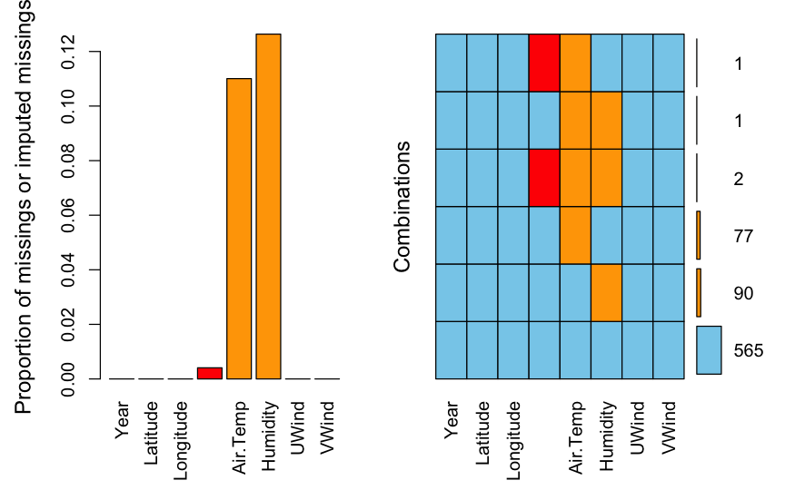

```r
aggr(tao_i_knn, delimiter="_imp", numbers=TRUE, prop=c(TRUE,FALSE))
```

```
not enough horizontal space to display frequencies
```

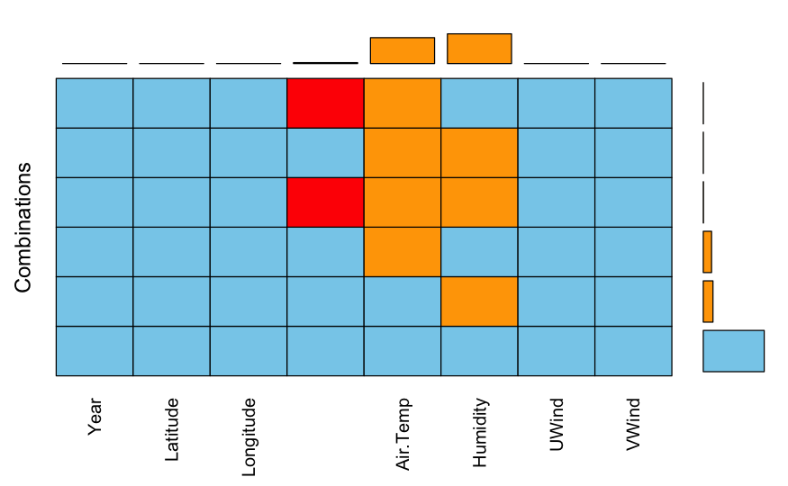

```r
aggr(tao_i_knn,delimiter="_imp",numbers=TRUE, prop=c(TRUE,FALSE), combined = TRUE)
```

```
Click in in the left margin to switch to the previous variable or in the right margin to switch to the next variable.
To regain use of the VIM GUI and the R console, click anywhere else in the graphics window.
```

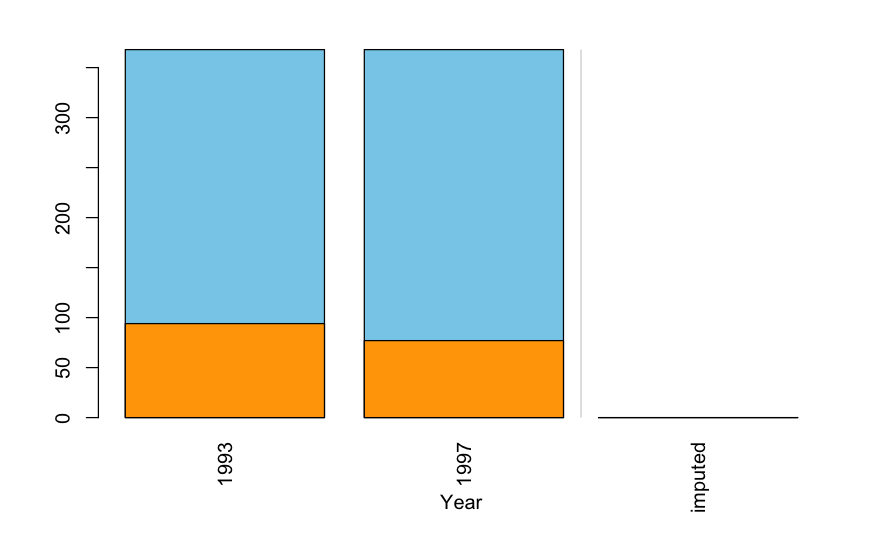

```r
barMiss(tao_i_knn, delimiter="imp", selection="any")
```